# Credit Card Fraud Analysis

Each instance in the dataset represents a feature-engineered, synthetic bank account application generated by a deep learning model titled Conditional Tabular Generative Adversarial Network (CTGAN) trained on real-world anonymized bank application data. Dataset derived from Kaggle Bank Account Fraud Dataset Suite (NeurIPS 2022) (https://www.kaggle.com/datasets/sgpjesus/bank-account-fraud-dataset-neurips-2022?select=Base.csv).

- Dataset suite Github homepage: https://github.com/feedzai/bank-account-fraud/tree/main

### Setting up the Data

```python
import pandas as pd
import numpy as np
import os
os.getcwd()
```

```
'/Users/smarr/Documents/Data Sets/Credit Card Fraud Analysis'
```

```python
CreditCardDf = pd.read_csv('Base.csv')
len(CreditCardDf)
```

```
1000000
```

- We've got a large dataframe at 1,000,000 rows.

```python
CreditCardDf.head()
```

|  | fraud_bool | income | name_email_similarity | prev_address_months_count | current_address_months_count | customer_age | days_since_request | intended_balcon_amount | payment_type | zip_count_4w | ... | has_other_cards | proposed_credit_limit | foreign_request | source | session_length_in_minutes | device_os | keep_alive_session | device_distinct_emails_8w | device_fraud_count | month |
| --- | --- | --- | --- | --- | --- | --- | --- | --- | --- | --- | --- | --- | --- | --- | --- | --- | --- | --- | --- | --- | --- |
| 0 | 0 | 0.3 | 0.986506 | -1 | 25 | 40 | 0.006735 | 102.453711 | AA | 1059 | ... | 0 | 1500.0 | 0 | INTERNET | 16.224843 | linux | 1 | 1 | 0 | 0 |
| 1 | 0 | 0.8 | 0.617426 | -1 | 89 | 20 | 0.010095 | -0.849551 | AD | 1658 | ... | 0 | 1500.0 | 0 | INTERNET | 3.363854 | other | 1 | 1 | 0 | 0 |
| 2 | 0 | 0.8 | 0.996707 | 9 | 14 | 40 | 0.012316 | -1.490386 | AB | 1095 | ... | 0 | 200.0 | 0 | INTERNET | 22.730559 | windows | 0 | 1 | 0 | 0 |
| 3 | 0 | 0.6 | 0.475100 | 11 | 14 | 30 | 0.006991 | -1.863101 | AB | 3483 | ... | 0 | 200.0 | 0 | INTERNET | 15.215816 | linux | 1 | 1 | 0 | 0 |
| 4 | 0 | 0.9 | 0.842307 | -1 | 29 | 40 | 5.742626 | 47.152498 | AA | 2339 | ... | 0 | 200.0 | 0 | INTERNET | 3.743048 | other | 0 | 1 | 0 | 0 |

5 rows × 32 columns

- Ensuring our data looks proper.
- Noticing some data in our prev_address_months_count contain -1, an indication of missing data. Will inspect more data to determine the missingness of our dataset.

```python
CreditCardDf.head(30)
```

|  | fraud_bool | income | name_email_similarity | prev_address_months_count | current_address_months_count | customer_age | days_since_request | intended_balcon_amount | payment_type | zip_count_4w | ... | has_other_cards | proposed_credit_limit | foreign_request | source | session_length_in_minutes | device_os | keep_alive_session | device_distinct_emails_8w | device_fraud_count | month |
| --- | --- | --- | --- | --- | --- | --- | --- | --- | --- | --- | --- | --- | --- | --- | --- | --- | --- | --- | --- | --- | --- |
| 0 | 0 | 0.3 | 0.986506 | -1 | 25 | 40 | 0.006735 | 102.453711 | AA | 1059 | ... | 0 | 1500.0 | 0 | INTERNET | 16.224843 | linux | 1 | 1 | 0 | 0 |
| 1 | 0 | 0.8 | 0.617426 | -1 | 89 | 20 | 0.010095 | -0.849551 | AD | 1658 | ... | 0 | 1500.0 | 0 | INTERNET | 3.363854 | other | 1 | 1 | 0 | 0 |
| 2 | 0 | 0.8 | 0.996707 | 9 | 14 | 40 | 0.012316 | -1.490386 | AB | 1095 | ... | 0 | 200.0 | 0 | INTERNET | 22.730559 | windows | 0 | 1 | 0 | 0 |
| 3 | 0 | 0.6 | 0.475100 | 11 | 14 | 30 | 0.006991 | -1.863101 | AB | 3483 | ... | 0 | 200.0 | 0 | INTERNET | 15.215816 | linux | 1 | 1 | 0 | 0 |
| 4 | 0 | 0.9 | 0.842307 | -1 | 29 | 40 | 5.742626 | 47.152498 | AA | 2339 | ... | 0 | 200.0 | 0 | INTERNET | 3.743048 | other | 0 | 1 | 0 | 0 |
| 5 | 0 | 0.6 | 0.294840 | -1 | 369 | 30 | 0.024232 | -1.232556 | AD | 1204 | ... | 0 | 200.0 | 0 | INTERNET | 6.987316 | linux | 1 | 1 | 0 | 0 |
| 6 | 0 | 0.2 | 0.773085 | 22 | 4 | 40 | 0.006919 | -0.544676 | AB | 1998 | ... | 0 | 200.0 | 0 | INTERNET | 28.199923 | x11 | 1 | 1 | 0 | 0 |
| 7 | 0 | 0.8 | 0.153880 | -1 | 103 | 40 | 0.045122 | -1.101184 | AB | 1548 | ... | 1 | 200.0 | 0 | INTERNET | 11.234264 | other | 1 | 1 | 0 | 0 |
| 8 | 0 | 0.3 | 0.523655 | 21 | 2 | 30 | 0.035206 | -0.955737 | AB | 1781 | ... | 0 | 200.0 | 0 | INTERNET | 5.329387 | other | 1 | 1 | 0 | 0 |
| 9 | 0 | 0.8 | 0.834475 | -1 | 134 | 20 | 0.017245 | -1.356393 | AD | 3113 | ... | 0 | 1500.0 | 0 | INTERNET | 4.103970 | other | 1 | 1 | 0 | 0 |
| 10 | 0 | 0.9 | 0.475015 | -1 | 67 | 50 | 0.008162 | -0.947659 | AB | 2998 | ... | 0 | 1500.0 | 0 | INTERNET | 2.892488 | other | 1 | 1 | 0 | 0 |
| 11 | 0 | 0.8 | 0.333013 | -1 | 14 | 40 | 0.000308 | 53.106292 | AA | 2355 | ... | 0 | 1500.0 | 0 | INTERNET | 32.908787 | other | 1 | 1 | 0 | 0 |
| 12 | 0 | 0.1 | 0.767432 | -1 | 34 | 20 | 0.021346 | -0.669856 | AB | 2491 | ... | 0 | 200.0 | 0 | INTERNET | 4.199729 | other | 0 | 2 | 0 | 0 |
| 13 | 0 | 0.9 | 0.866089 | -1 | 33 | 30 | 0.034662 | -0.975230 | AD | 1249 | ... | 0 | 1500.0 | 0 | INTERNET | 20.607229 | macintosh | 0 | 1 | 0 | 0 |
| 14 | 0 | 0.9 | 0.052615 | -1 | 156 | 30 | 0.025660 | -1.570164 | AD | 1685 | ... | 0 | 200.0 | 0 | INTERNET | 6.324050 | linux | 1 | 1 | 0 | 0 |
| 15 | 0 | 0.9 | 0.520718 | -1 | 31 | 50 | 0.005729 | -1.008223 | AC | 597 | ... | 0 | 200.0 | 0 | INTERNET | 3.731970 | linux | 1 | 1 | 0 | 0 |
| 16 | 0 | 0.8 | 0.122370 | -1 | 20 | 30 | 0.023472 | -0.881640 | AD | 1655 | ... | 0 | 200.0 | 0 | INTERNET | 7.836945 | windows | 1 | 1 | 0 | 0 |
| 17 | 0 | 0.6 | 0.482906 | -1 | 38 | 40 | 0.037925 | -0.994614 | AC | 2774 | ... | 0 | 200.0 | 0 | INTERNET | 4.486326 | other | 1 | 1 | 0 | 0 |
| 18 | 0 | 0.2 | 0.527751 | 13 | 114 | 20 | 0.003171 | -0.848347 | AB | 4389 | ... | 0 | 200.0 | 0 | INTERNET | 2.838194 | windows | 1 | 2 | 0 | 0 |
| 19 | 0 | 0.5 | 0.674870 | -1 | 372 | 30 | 0.004406 | 30.300980 | AA | 2069 | ... | 0 | 1500.0 | 0 | INTERNET | 6.336455 | other | 1 | 1 | 0 | 0 |
| 20 | 0 | 0.7 | 0.732086 | -1 | 54 | 30 | 0.010840 | 43.998234 | AA | 2060 | ... | 0 | 200.0 | 0 | INTERNET | 1.627588 | linux | 1 | 1 | 0 | 0 |
| 21 | 0 | 0.1 | 0.428625 | -1 | 60 | 20 | 0.017245 | -1.415332 | AB | 3418 | ... | 0 | 200.0 | 0 | INTERNET | 3.462537 | other | 1 | 1 | 0 | 0 |
| 22 | 0 | 0.1 | 0.256975 | -1 | 44 | 20 | 0.007484 | -1.293428 | AC | 1668 | ... | 1 | 500.0 | 0 | INTERNET | 2.367118 | linux | 0 | 1 | 0 | 0 |
| 23 | 0 | 0.7 | 0.450057 | -1 | 30 | 20 | 0.039597 | -0.862956 | AB | 4254 | ... | 0 | 200.0 | 0 | INTERNET | 4.377892 | other | 1 | 1 | 0 | 0 |
| 24 | 0 | 0.5 | 0.178738 | 26 | 8 | 30 | 0.028241 | -1.466146 | AB | 1408 | ... | 0 | 200.0 | 0 | INTERNET | 2.818489 | linux | 1 | 1 | 0 | 0 |
| 25 | 0 | 0.9 | 0.102745 | -1 | 203 | 50 | 0.005173 | -0.661988 | AB | 3453 | ... | 0 | 1000.0 | 0 | INTERNET | 10.480853 | linux | 1 | 1 | 0 | 0 |
| 26 | 0 | 0.4 | 0.043498 | 33 | 9 | 40 | 0.013691 | -1.121680 | AB | 4460 | ... | 0 | 200.0 | 0 | INTERNET | 25.369778 | linux | 1 | 1 | 0 | 0 |
| 27 | 0 | 0.6 | 0.084088 | -1 | 104 | 30 | 0.011475 | -1.793004 | AB | 1972 | ... | 1 | 200.0 | 0 | INTERNET | 4.502007 | macintosh | 1 | 1 | 0 | 0 |
| 28 | 0 | 0.2 | 0.030562 | 27 | 7 | 40 | 20.129567 | -1.558473 | AB | 1619 | ... | 0 | 200.0 | 0 | INTERNET | 7.523309 | linux | 0 | 1 | 0 | 0 |
| 29 | 0 | 0.9 | 0.272416 | -1 | 35 | 40 | 0.000048 | -0.607132 | AD | 2243 | ... | 0 | 200.0 | 0 | INTERNET | 2.598805 | windows | 1 | 1 | 0 | 0 |

30 rows × 32 columns

- Our prev_address_months_count column contains a significant number of -1s, indicating missing data. Other columns may contain missing data, aswell.
- The following code will impute NaN for our -1 values.

```python
CreditCardDf.replace(-1,np.nan, inplace=True)
CreditCardDf.head()
```

|  | fraud_bool | income | name_email_similarity | prev_address_months_count | current_address_months_count | customer_age | days_since_request | intended_balcon_amount | payment_type | zip_count_4w | ... | has_other_cards | proposed_credit_limit | foreign_request | source | session_length_in_minutes | device_os | keep_alive_session | device_distinct_emails_8w | device_fraud_count | month |
| --- | --- | --- | --- | --- | --- | --- | --- | --- | --- | --- | --- | --- | --- | --- | --- | --- | --- | --- | --- | --- | --- |
| 0 | 0 | 0.3 | 0.986506 | NaN | 25.0 | 40 | 0.006735 | 102.453711 | AA | 1059 | ... | 0 | 1500.0 | 0 | INTERNET | 16.224843 | linux | 1 | 1.0 | 0 | 0 |
| 1 | 0 | 0.8 | 0.617426 | NaN | 89.0 | 20 | 0.010095 | -0.849551 | AD | 1658 | ... | 0 | 1500.0 | 0 | INTERNET | 3.363854 | other | 1 | 1.0 | 0 | 0 |
| 2 | 0 | 0.8 | 0.996707 | 9.0 | 14.0 | 40 | 0.012316 | -1.490386 | AB | 1095 | ... | 0 | 200.0 | 0 | INTERNET | 22.730559 | windows | 0 | 1.0 | 0 | 0 |
| 3 | 0 | 0.6 | 0.475100 | 11.0 | 14.0 | 30 | 0.006991 | -1.863101 | AB | 3483 | ... | 0 | 200.0 | 0 | INTERNET | 15.215816 | linux | 1 | 1.0 | 0 | 0 |
| 4 | 0 | 0.9 | 0.842307 | NaN | 29.0 | 40 | 5.742626 | 47.152498 | AA | 2339 | ... | 0 | 200.0 | 0 | INTERNET | 3.743048 | other | 0 | 1.0 | 0 | 0 |

5 rows × 32 columns

```python
CreditCardDf.isna().sum()
```

```
fraud_bool                               0
income                                   0
name_email_similarity                    0
prev_address_months_count           712920
current_address_months_count          4254
customer_age                             0
days_since_request                       0
intended_balcon_amount                   0
payment_type                             0
zip_count_4w                             0
velocity_6h                              0
velocity_24h                             0
velocity_4w                              0
bank_branch_count_8w                     0
date_of_birth_distinct_emails_4w         0
employment_status                        0
credit_risk_score                      488
email_is_free                            0
housing_status                           0
phone_home_valid                         0
phone_mobile_valid                       0
bank_months_count                   253635
has_other_cards                          0
proposed_credit_limit                    0
foreign_request                          0
source                                   0
session_length_in_minutes             2015
device_os                                0
keep_alive_session                       0
device_distinct_emails_8w              359
device_fraud_count                       0
month                                    0
dtype: int64
```

## Basic EDA and Visualizations

```python
import seaborn as sns
import matplotlib.pyplot as plt
```

### Class Distribution

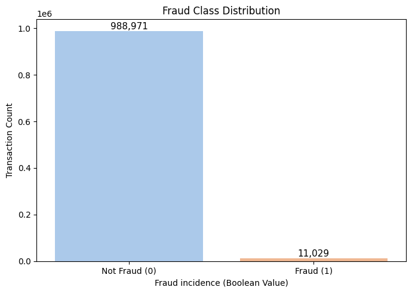

```python
FraudClassCount=CreditCardDf['fraud_bool'].value_counts()
FraudClassPercent=CreditCardDf['fraud_bool'].value_counts(normalize=True)*100

plt.figure(figsize=(7,5))
sns.barplot(x=FraudClassCount.index, y=FraudClassCount.values, palette='pastel')

plt.xticks([0,1],['Not Fraud (0)','Fraud (1)'])
plt.xlabel('Fraud incidence (Boolean Value)')
plt.ylabel('Transaction Count')
plt.title('Fraud Class Distribution')

for i, count in enumerate(FraudClassCount.values):{
    plt.text(i, count+50, f'{count:,}', ha ='center', va='bottom', fontsize=11)
}
plt.tight_layout()
plt.savefig('assets/images/FraudClassDistribution.png', dpi=300, bbox_inches='tight')
plt.show()
```

- The data is highly skewed towards non fraudulent transactions, which is why classification models like XGBoost / LightGBM or Support Vector Machine (SVM) can be excellent for modeling fraud incidence.

#### Numeric Feature Distribution

- Prior to producing our plots, we'd like to identify the most high-potential features that can provide the most insight with respect to associating our data with fraudulent transaction outcomes.
  - Computing Basic stats for every numeric feature, grouped by our fraud boolean value, will give us basic insight into our data landscape.

```python
numeric_cols=CreditCardDf.select_dtypes(include='number').columns.drop('fraud_bool')
CreditCardDf.groupby('fraud_bool')[numeric_cols].mean().T.sort_values(by=1,ascending=False)
```

| fraud_bool | 0 | 1 |
| --- | --- | --- |
| velocity_6h | 5670.664988 | 5183.913444 |
| velocity_4w | 4857.444566 | 4755.844185 |
| velocity_24h | 4771.528849 | 4613.138798 |
| zip_count_4w | 1572.138693 | 1622.311542 |
| proposed_credit_limit | 512.303162 | 833.986762 |
| credit_risk_score | 130.534808 | 177.590353 |
| bank_branch_count_8w | 184.923747 | 133.976426 |
| current_address_months_count | 86.649009 | 114.948343 |
| prev_address_months_count | 60.648563 | 83.551955 |
| customer_age | 33.609125 | 40.858645 |
| bank_months_count | 14.839331 | 17.362317 |
| session_length_in_minutes | 7.554580 | 8.244608 |
| date_of_birth_distinct_emails_4w | 9.526521 | 7.443195 |
| intended_balcon_amount | 8.713907 | 3.962009 |
| month | 3.285582 | 3.565962 |
| device_distinct_emails_8w | 1.018355 | 1.080181 |
| days_since_request | 1.025383 | 1.054615 |
| phone_mobile_valid | 0.890112 | 0.850576 |
| income | 0.561313 | 0.686635 |
| email_is_free | 0.528423 | 0.661075 |
| name_email_similarity | 0.494815 | 0.393161 |
| keep_alive_session | 0.579571 | 0.341645 |
| phone_home_valid | 0.418906 | 0.253060 |
| has_other_cards | 0.224533 | 0.084414 |
| foreign_request | 0.024962 | 0.050322 |
| device_fraud_count | 0.000000 | 0.000000 |

- This provides excellent insight - velocity demonstrates the number of credit card applications submitted per hour over the denoted time frame (e.g. 6h, 4w) over a shared context, such as a device, IP Address, Zip Code, Geolocation, session ID, or other identifying information. These columns can detect bursts in application activity, which could be highly predictive of fraud incidence.
- Zip Count (4w) captures the number of credit card applications completed in a shared zip code over a 4-week period. This feature could identify potential fraud rings that operate in the same zip code.
- Our data set providers were careful to strip out sensitive identifying information such as ZipCode or IP information as its inclusion would pose a serious information security breach.

### Kernel Density Estimate plots for numerical feature distribution by Fraud Status

- the following code will select the top eight columns of interest to represent in a series of Kernel Density estimate plots to visualize the numerical differences in each feature across fraud incidence class.

```python
top_kde_features = ['velocity_6h', 'velocity_4w','velocity_24h','zip_count_4w','proposed_credit_limit','credit_risk_score','bank_branch_count_8w','session_length_in_minutes']
```

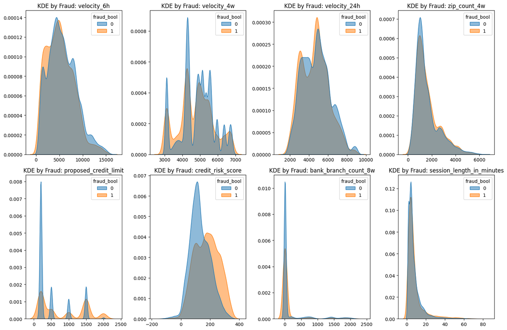

```python
plt.figure(figsize=(15,10))
for i, columns in enumerate(top_kde_features, 1):
    plt.subplot(2,4,i)
    sns.kdeplot(data=CreditCardDf,x=columns,hue='fraud_bool',fill=True,common_norm=False,alpha=0.5)
    plt.title(f'KDE by Fraud: {columns}')
    plt.xlabel('')
    plt.ylabel('')

plt.tight_layout()
plt.savefig('assets/images/kde_plot_numerical_features_class_status.png')
plt.show()
plt.close()
```

##### There's a lot to work with here, but most notably:

- Non-fraudulent applications tend to have a lower credit risk score than fraudulent ones.
- Both frauduluent and non-fraudulent applications tend to have similar 6 hour, 24 hour, and 4 week velocities, in addition to similar session length and zip-count.
  - This may seem like an innocous finding at first, however this informs us greatly about the densely clustered values among fraudulent application samples. As the data is highly skewed towards non-fraudulent applications, then intuitively the fraudulent samples' KDE peaks will inherently be lower. Therefore, for our plots that have comparable KDE peaks across fraudulent and non-fraudulent samples, the feature in question are strong indicators of fraud.

### Categorical Feature distribution by Fraud Status

```python
## Isolate categorical columns by object data type
categorical_cols = CreditCardDf.select_dtypes(include='object').columns
len(categorical_cols)
```

```
5
```

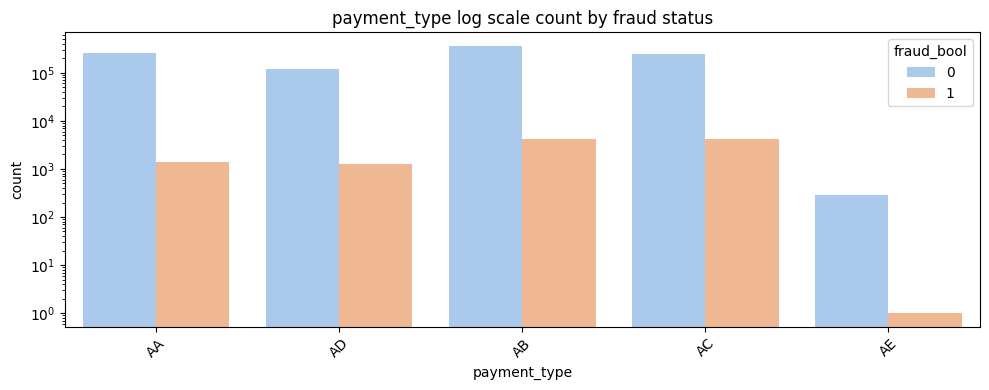

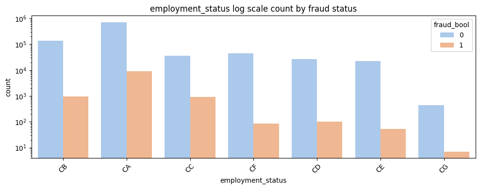

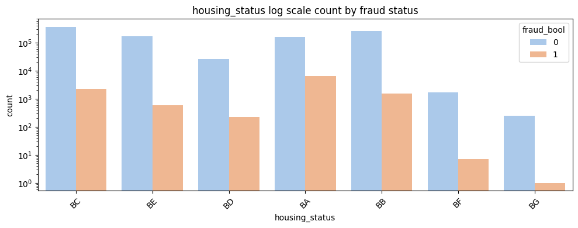

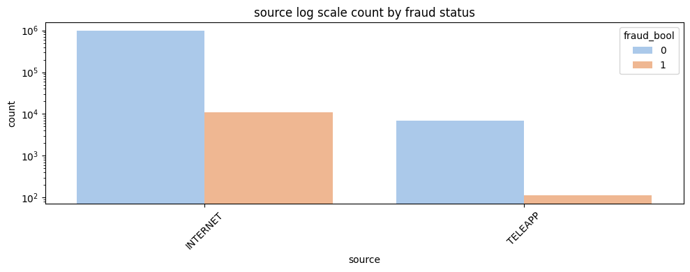

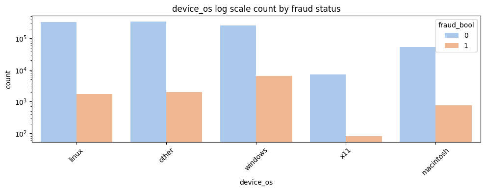

```python
for cols in categorical_cols:
    plt.figure(figsize=(10,4))
    sns.countplot(data=CreditCardDf,x=cols,hue='fraud_bool', palette= 'pastel')
    plt.title(f'{cols} log scale count by fraud status')
    plt.yscale('log')
    plt.xticks(rotation=45)
    plt.tight_layout()
    plt.savefig(f'assets/images/Categorical_feature_distribution_by_{cols}.png')

plt.show()
```

Disclaimer: The variables Housing Status, Employment Status, and Payment Type have been anonymized to preserve customer privacy. Although their categorical labels do not reflect real-world semantics, they retain predictive value and may still indicate patterns associated with fraudulent credit card applications.

### Correlation Heatmap

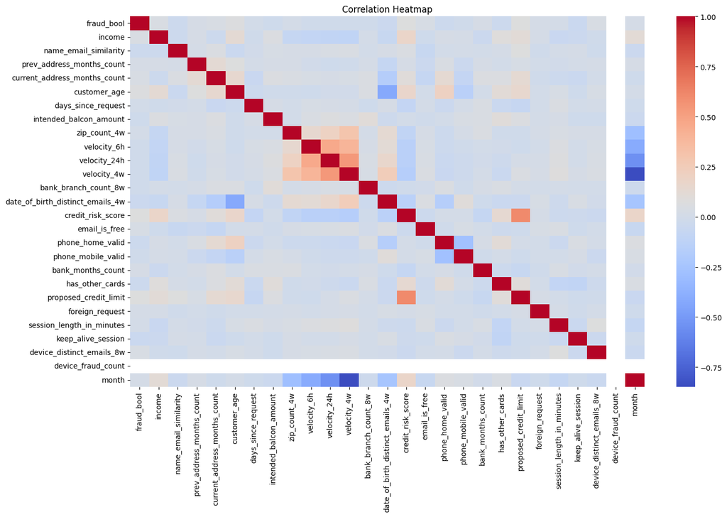

```python
plt.figure(figsize=(15,10))
corr=CreditCardDf.corr(numeric_only=True)
sns.heatmap(corr,cmap='coolwarm',annot=False,fmt='.2f')
plt.title('Correlation Heatmap')
plt.tight_layout()
plt.savefig('assets/images/Correlation_Heatmap.png')
plt.show()
```

## Scaling and Modeling

- Our data is highly imbalanced, with only 1% of the data containing the fraud class.
- Our modeling analysis will consist of a comparison between XGBoost / LightGBM and Logistic Regression, additionally incorporating Oversampling techniques and meta-modeling techniques such as SMOTE/ADASYN and Ensembles & Stacking to enrich the comparitive analysis and the ensuing predictive outcomes.
- The below code will split our data into training and test sets and impute Nan Values in our columns with median values to preserve consistency and integrity of data and to comply with copying our data for our oversampling technique.

```python
from sklearn.model_selection import train_test_split
CreditCardDfM=CreditCardDf.drop(columns='fraud_bool')

## Splitting the Data
x_train, x_test, y_train, y_test = train_test_split(CreditCardDfM,
                                                    CreditCardDf['fraud_bool'],test_size=0.2,
                                                    stratify=CreditCardDf['fraud_bool'], random_state=42)

## Must split data into numerical and categorical features to impute values correctly
CreditCardDfMNum=CreditCardDfM.select_dtypes(include='number').columns
CreditCardDfMCate=CreditCardDfM.select_dtypes(include='object').columns

from sklearn.impute import SimpleImputer
imputer_num=SimpleImputer(strategy='median')
x_train[CreditCardDfMNum] = imputer_num.fit_transform(x_train[CreditCardDfMNum])
x_test[CreditCardDfMNum] = imputer_num.fit_transform(x_test[CreditCardDfMNum])

imputer_cate=SimpleImputer(strategy='most_frequent')
x_train[CreditCardDfMCate] = imputer_cate.fit_transform(x_train[CreditCardDfMCate])
x_test[CreditCardDfMCate] = imputer_cate.fit_transform(x_test[CreditCardDfMCate])
```

```python
## Standard Scaling
from sklearn.preprocessing import StandardScaler
scaler = StandardScaler()
x_train[CreditCardDfMNum] = scaler.fit_transform(x_train[CreditCardDfMNum])
x_test[CreditCardDfMNum] = scaler.fit_transform(x_test[CreditCardDfMNum])
```

```python
## Label Encoding
from sklearn.preprocessing import OneHotEncoder
encoder = OneHotEncoder(handle_unknown='ignore', sparse_output=False)

x_train_cat = encoder.fit_transform(x_train[CreditCardDfMCate])
x_test_cat = encoder.transform(x_test[CreditCardDfMCate])

x_train_num = x_train.drop(columns=CreditCardDfMCate).values
x_test_num = x_test.drop(columns=CreditCardDfMCate).values

x_train = np.hstack([x_train_num, x_train_cat])
x_test = np.hstack([x_test_num, x_test_cat])
```

- Creating a second set of training data to apply SMOTE oversampling technique

```python
x_train_og=x_train.copy()
y_train_og=y_train.copy()

from imblearn.over_sampling import SMOTE
smote = SMOTE(random_state=42)
x_train_smote, y_train_smote = smote.fit_resample(x_train, y_train)
```

## Logistic Regression

##### With and Without SMOTE-altered data

```python
from sklearn.linear_model import LogisticRegression
from sklearn.metrics import classification_report, confusion_matrix, precision_recall_curve, auc

## Training both models
log_reg_orig = LogisticRegression(max_iter=1000, random_state=42)
log_reg_orig.fit(x_train_og,y_train_og)

log_reg_smote = LogisticRegression(max_iter=1000, random_state=42)
log_reg_smote.fit(x_train_smote,y_train_smote)
```

```
LogisticRegression(max_iter=1000, random_state=42)
```

```python
## Predictions
y_pred_orig = log_reg_orig.predict(x_test)
y_pred_smote = log_reg_smote.predict(x_test)
```

```python
## Evaluating and comparing the models
print("Logistic Regression with Original Training Data:")
print(confusion_matrix(y_test, y_pred_orig))
print(classification_report(y_test, y_pred_orig))

print("Logistic Regression with SMOTE-altered Training Data:")
print(confusion_matrix(y_test, y_pred_smote))
print(classification_report(y_test, y_pred_smote))
```

```
Logistic Regression with Original Training Data:
[[197777     17]
 [  2176     30]]
              precision    recall  f1-score   support

           0       0.99      1.00      0.99    197794
           1       0.64      0.01      0.03      2206

    accuracy                           0.99    200000
   macro avg       0.81      0.51      0.51    200000
weighted avg       0.99      0.99      0.98    200000

Logistic Regression with SMOTE-altered Training Data:
[[162575  35219]
 [   514   1692]]
              precision    recall  f1-score   support

           0       1.00      0.82      0.90    197794
           1       0.05      0.77      0.09      2206

    accuracy                           0.82    200000
   macro avg       0.52      0.79      0.49    200000
weighted avg       0.99      0.82      0.89    200000
```

#### Let's discuss the results here:

Our Logistic Regression with Original Training data:

- Correctly identified almost all non-fraud applications.
- Only misclassified 17 applications as frauds.
- mistook 2176 frauds for regular applications.
- Only predicted 30 fraudulent applications.

Out of all fraud applications, 64% of the predictions were correct (recall, only 30 applications). Recall is at an abysmal 0.01, meaning we caught only 1% of fraudulent applications. F-1 score indicates a terrible balance of precision and recall ~ 0.03. Overall accuracy, at 0.99, is misleading since our data is inherently significantly skewed.

Our Logistic Regression with SMOTE-altered Training data:

- Correctly identified less non-fraudulent applications than our LR with original, non-SMOTE data.
- Missed 514 fraudulent applications.
- Predicted over 1692 fraudulent applications, a huge step-up from our original training data.
- Predicted fraud for 35219 non-fraudulent applications.

Out of all fraud applications, 5% of the predictions were correct (recall, 1692 applications). Recall is at a much improved 0.77, meaning we caught up to 77% of fraudulent applications. F-1 score indicates a subpar balance of precision and recall ~ 0.09. Overall accuracy, at 0.82, is underwhelming and worse-off than our logistic regression completed with non-SMOTE training data. Our Smote data allowed our model to catch much more fraudulent transactions, however its casting a much, much wider net, resulting in false positives.

### Precision-Recall curves for Logistic Regression Visualization

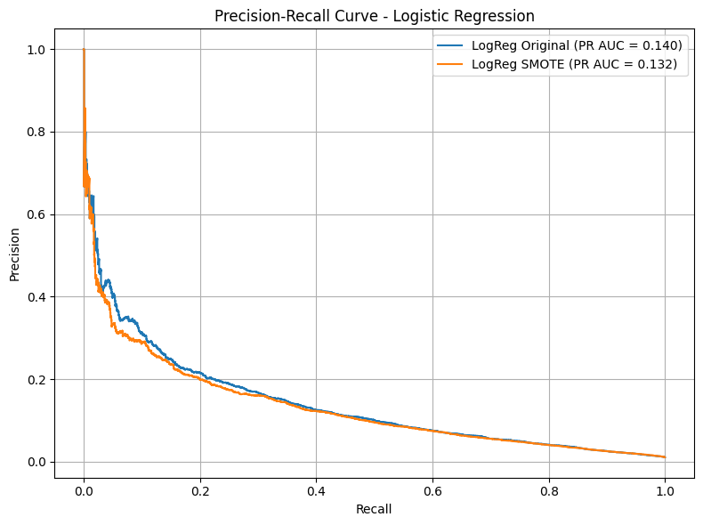

```python
import matplotlib.pyplot as plt

def precision_plot(model,x_test,y_test,label):
    y_scores = model.predict_proba(x_test)[:, 1]
    precision, recall, _ = precision_recall_curve(y_test, y_scores)
    pr_auc = auc(recall, precision)
    plt.plot(recall, precision, label=f'{label} (PR AUC = {pr_auc:.3f})')

plt.figure(figsize=(8, 6))
precision_plot(log_reg_orig, x_test, y_test, "LogReg Original")
precision_plot(log_reg_smote, x_test, y_test, "LogReg SMOTE")
plt.xlabel("Recall")
plt.ylabel("Precision")
plt.title("Precision-Recall Curve - Logistic Regression")
plt.legend()
plt.grid()
plt.tight_layout()
plt.savefig('assets/images/Precision-Recall_Curve_LR.png')
plt.show()
```

What do our findings show?

The overall shape of the curves validates the classification reports: the original model is conservative and precise, while the SMOTE model is more aggressive in catching fraud but generates many false alarms In general, SMOTE improves fraud detection recall, but significantly worsens precision — meaning your model is better at catching frauds, but triggers a lot of false alarms in the process.

## Extreme Gradient Boosting (XGBoost) analysis

##### XGBoost and LightGBM are two of the most powerful models for tabular credit card fraud data

```python
## Below code will label encode our categorical values, replacing those strings with integer values
## Tree-based models such as XGBoost and LightGBM care about splits in data, not numeric distances (as was the case with One Hot encoding)

# We'll need to recover and re-run our pre-OneHotEncoding x_train arrays to bypass errors associated with running them through two encoding techniques
from sklearn.preprocessing import LabelEncoder

x_train, x_test, y_train, y_test = train_test_split(CreditCardDfM,
                                                    CreditCardDf['fraud_bool'],test_size=0.2,
                                                    stratify=CreditCardDf['fraud_bool'], random_state=42)

CreditCardDfMNum=CreditCardDfM.select_dtypes(include='number').columns
CreditCardDfMCate=CreditCardDfM.select_dtypes(include='object').columns

imputer_num=SimpleImputer(strategy='median')
x_train[CreditCardDfMNum] = imputer_num.fit_transform(x_train[CreditCardDfMNum])
x_test[CreditCardDfMNum] = imputer_num.transform(x_test[CreditCardDfMNum])

imputer_cate=SimpleImputer(strategy='most_frequent')
x_train[CreditCardDfMCate] = imputer_cate.fit_transform(x_train[CreditCardDfMCate])
x_test[CreditCardDfMCate] = imputer_cate.fit_transform(x_test[CreditCardDfMCate])

scaler = StandardScaler()
x_train[CreditCardDfMNum] = scaler.fit_transform(x_train[CreditCardDfMNum])
x_test[CreditCardDfMNum] = scaler.fit_transform(x_test[CreditCardDfMNum])

for col in CreditCardDfMCate:
    le = LabelEncoder()
    x_train[col] = le.fit_transform(x_train[col])
    x_test[col] = le.transform(x_test[col])


x_train_og=x_train.copy()
y_train_og=y_train.copy()

from imblearn.over_sampling import SMOTE
smote = SMOTE(random_state=42)
x_train_smote, y_train_smote = smote.fit_resample(x_train, y_train)
```

```python
# The following code will train xgboost on our non-smote, imbalanced data
import xgboost as xgb
from sklearn.metrics import classification_report, confusion_matrix, precision_recall_curve, roc_auc_score, auc, roc_curve

xgb_model_orig=xgb.XGBClassifier(Use_label_encoder=False, eval_metric='logloss',random_state=42)
xgb_model_orig.fit(x_train_og,y_train_og)

# The following code will train xgboost on our smote, balanced data
xgb_model_smote=xgb.XGBClassifier(Use_label_encoder=False, eval_metric='logloss',random_state=42)
xgb_model_smote.fit(x_train_smote,y_train_smote)
```

```
XGBClassifier(Use_label_encoder=False, base_score=None, booster=None,
              callbacks=None, colsample_bylevel=None, colsample_bynode=None,
              colsample_bytree=None, device=None, early_stopping_rounds=None,
              enable_categorical=False, eval_metric='logloss',
              feature_types=None, feature_weights=None, gamma=None,
              grow_policy=None, importance_type=None,
              interaction_constraints=None, learning_rate=None, max_bin=None,
              max_cat_threshold=None, max_cat_to_onehot=None,
              max_delta_step=None, max_depth=None, max_leaves=None,
              min_child_weight=None, missing=nan, monotone_constraints=None,
              multi_strategy=None, n_estimators=None, n_jobs=None, ...)
```

```python
y_pred_xgb_orig = xgb_model_orig.predict(x_test)
y_score_xgb_orig = xgb_model_orig.predict_proba(x_test)[:,1]

y_pred_xgb_smote = xgb_model_smote.predict(x_test)
y_score_xgb_smote = xgb_model_smote.predict_proba(x_test)[:,1]

print("XGBoost with original, imbalanced data:")
print(confusion_matrix(y_test, y_pred_xgb_orig))
print(classification_report(y_test, y_pred_xgb_orig))

print("XGBoost with Smote-applied, balanced data:")
print(confusion_matrix(y_test, y_pred_xgb_smote))
print(classification_report(y_test, y_pred_xgb_smote))
```

```
XGBoost with original, imbalanced data:
[[197687    107]
 [  2133     73]]
              precision    recall  f1-score   support

           0       0.99      1.00      0.99    197794
           1       0.41      0.03      0.06      2206

    accuracy                           0.99    200000
   macro avg       0.70      0.52      0.53    200000
weighted avg       0.98      0.99      0.98    200000

XGBoost with Smote-applied, balanced data:
[[ 67728 130066]
 [   210   1996]]
              precision    recall  f1-score   support

           0       1.00      0.34      0.51    197794
           1       0.02      0.90      0.03      2206

    accuracy                           0.35    200000
   macro avg       0.51      0.62      0.27    200000
weighted avg       0.99      0.35      0.50    200000
```

#### Let's discuss the results here:

XGBoost with Original, Imbalanced Training Data:

- Correctly identified 197,687 out of 197,794 non-fraud cases (very high precision on the majority class).
- Incorrectly flagged 107 non-fraud cases as fraud (slightly more false positives than Logistic Regression).
- Missed 2,133 out of 2,206 fraud cases — meaning only 73 frauds were caught.
- Precision for fraud predictions was 41%, but recall was just 3%.

Although precision for the fraud class looks better than in Logistic Regression, recall remains extremely low — the model still missed 97% of fraud. The f1-score is low (0.06), indicating poor fraud detection. Accuracy remains high at 0.99, but again, this is misleading due to the dataset imbalance.

XGBoost with SMOTE-balanced Training Data:

- Correctly flagged 1,996 out of 2,206 fraud cases — a huge recall boost (90%).
- Mistakenly labeled 130,066 non-fraud cases as fraud, a dramatic increase in false positives.
- Precision on fraud predictions dropped to just 2%.
- Overall accuracy plummeted to 35% due to overwhelming misclassification of legitimate transactions.

This version of XGBoost is extremely sensitive to fraud — catching almost all of it — but at the cost of flagging the majority of normal transactions incorrectly. The model has high recall but extremely poor precision and overall usability, reflecting an overly aggressive fraud detection behavior after SMOTE oversampling.

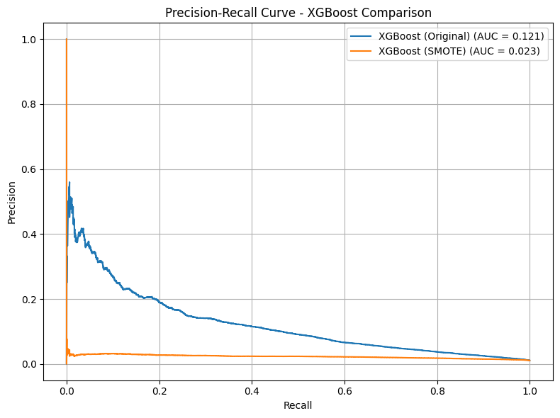

```python
def XGBoost_PR_curve(y_true, y_scores, label):
    precision, recall, _ = precision_recall_curve(y_true, y_scores)
    pr_auc = auc(recall, precision)
    plt.plot(recall, precision, label=f"{label} (AUC = {pr_auc:.3f})")

plt.figure(figsize=(8, 6))

# Curve for XGBoost - original training data
XGBoost_PR_curve(y_test, y_score_xgb_orig, "XGBoost (Original)")

# Curve for XGBoost - SMOTE training data
XGBoost_PR_curve(y_test, y_score_xgb_smote, "XGBoost (SMOTE)")

# Plot settings
plt.xlabel("Recall")
plt.ylabel("Precision")
plt.title("Precision-Recall Curve - XGBoost Comparison")
plt.legend()
plt.grid(True)
plt.tight_layout()
plt.savefig("assets/images/Precision-Recall Curve_XGBoost")
plt.show()
```

What do our findings show?

The original model is more conservative, yet far more trustworthy and usable for fraud detection in real-world applications.

#### Why did SMOTE hurt our XGBoost model so much?

- Synthetic points, as in the case of our oversampling technique in SMOTE, adds a lot of "noise" in the form of newly generated fraud samples, which can mislead the tree growth process.
- Our XGBoost model is incredibly vulnerable to synthetic patterns generated by SMOTE due to it being a high-capacity learner - these patterns don't generalize uniformly to the rest of the data, leading to a precipitous drop in precision score.

## Light Gradient Boosting Machine (GBM)

#### A faster and more efficient form of Gradient Boosting

```python
import lightgbm as lgb
lgb_model_orig = lgb.LGBMClassifier(random_state=42)
lgb_model_smotes = lgb.LGBMClassifier(random_state=42)

lgb_model_orig.fit(x_train_og, y_train)
lgb_model_smotes.fit(x_train_smote, y_train_smote)
```

[output not shown]

```
LGBMClassifier(random_state=42)
```

```python
y_pred_lgb_orig = lgb_model_orig.predict(x_test)
y_score_lgb_orig = lgb_model_orig.predict_proba(x_test)[:,1]

y_pred_lgb_smote = lgb_model_smotes.predict(x_test)
y_score_lgb_smote = lgb_model_smotes.predict_proba(x_test)[:,1]

print("LightGBM - Original Data")
print(confusion_matrix(y_test, y_pred_lgb_orig))
print(classification_report(y_test, y_pred_lgb_orig))

print("LightGBM - Balanced Data")
print(confusion_matrix(y_test, y_pred_lgb_smote))
print(classification_report(y_test, y_pred_lgb_smote))
```

```
LightGBM - Original Data
[[197653    141]
 [  2106    100]]
              precision    recall  f1-score   support

           0       0.99      1.00      0.99    197794
           1       0.41      0.05      0.08      2206

    accuracy                           0.99    200000
   macro avg       0.70      0.52      0.54    200000
weighted avg       0.98      0.99      0.98    200000

LightGBM - Balanced Data
[[   383 197411]
 [     0   2206]]
              precision    recall  f1-score   support

           0       1.00      0.00      0.00    197794
           1       0.01      1.00      0.02      2206

    accuracy                           0.01    200000
   macro avg       0.51      0.50      0.01    200000
weighted avg       0.99      0.01      0.00    200000
```

#### Let's discuss the results here:

Our LightGBM with Original Training Data:

Out of all fraud applications, 42% of the fraud predictions were correct, with a recall of 0.05, meaning we caught only 5% of actual frauds. The F1-score of 0.08 reflects a weak balance between precision and recall. While the overall accuracy is 0.99, this is misleading, as it simply reflects the model’s strong performance on the dominant non-fraud class.

### Importantly:

This catastrophic drop in precision is a textbook case of tree models overfitting to synthetic patterns introduced by SMOTE. Because LightGBM and XGBoost build decision splits on exact feature values, the interpolated samples from SMOTE inaccurately reflect the true structure of the data. Instead, they introduce unnatural boundaries the model vulnerably focuses on — allowing it to memorize synthetic "fraud zones" that don’t generalize, leading to massive false positive rates.

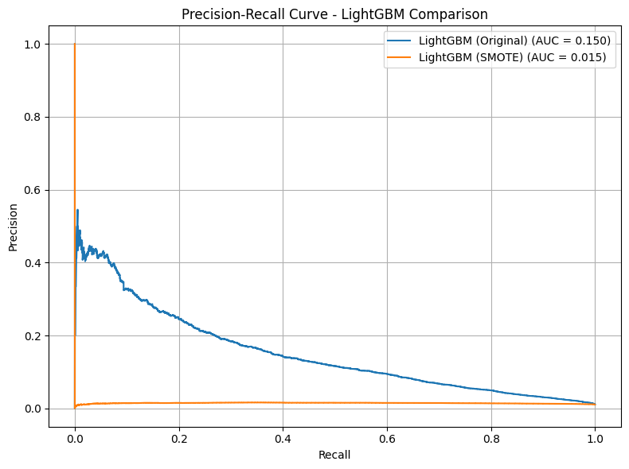

```python
def LightGBM_PR_Curve(y_true, y_scores, label):
    precision, recall, _ = precision_recall_curve(y_true, y_scores)
    pr_auc = auc(recall, precision)
    plt.plot(recall, precision, label=f"{label} (AUC = {pr_auc:.3f})")

plt.figure(figsize=(8, 6))

LightGBM_PR_Curve(y_test, y_score_lgb_orig, "LightGBM (Original)")

LightGBM_PR_Curve(y_test, y_score_lgb_smote, "LightGBM (SMOTE)")

plt.xlabel("Recall")
plt.ylabel("Precision")
plt.title("Precision-Recall Curve - LightGBM Comparison")
plt.legend()
plt.grid(True)
plt.tight_layout()
plt.savefig("assets/images/LightGBM_PR_Curve.png")
plt.show()
```

What do our findings show?

- For our LightGBM model trained on imbalanced data, precision steadily declines with increasing recall, which is expected. The model is cautious, but when it flags fraud, it's relatively accurate early on.
- Despite low recall, our model trained on imbalanced data retains predictive value — it makes some smart decisions in identifying true fraud.
- Our SMOTE Model's precision hovers near zero across all recall levels, meaning that almost all fraud predictions are false alarms.
- The curve confirms what we saw in the classification report: SMOTE completely destroyed LightGBM’s ability to distinguish legitimate from fraudulent behavior.

## Adding scale_pos_weight for LightGBM and XGBoost for proper fraud class weighting

##### Following Our failure to produce dependable models with SMOTE, scale_pos_weight will ensure our fraud data is properly weighted

```python
## the following code will estimate the relative weight of fraud cases compared to non-fraud casesin our data set
neg = sum(y_train == 0)
pos = sum(y_train == 1)
scale_pos_weight = neg / pos
```

```python
## The following code will re-run our XGBoost and LightGBM models, however we will disregard the SMOTE data and implement the scale_pos_weight parameter
xgb_weighted=xgb.XGBClassifier(scale_pos_weight=neg/pos, Use_label_encoder=False, eval_metric='logloss',random_state=42)
xgb_weighted.fit(x_train_og,y_train_og)

y_pred_xgb_weighted = xgb_weighted.predict(x_test)
y_score_xgb_weighted = xgb_weighted.predict_proba(x_test)[:,1]

print("XGBoost with scale_pos_weight")
print(confusion_matrix(y_test, y_pred_xgb_weighted))
print(classification_report(y_test, y_pred_xgb_weighted))

lgb_weighted = lgb.LGBMClassifier(scale_pos_weight=neg/pos, random_state=42)
lgb_weighted.fit(x_train_og, y_train_og)

y_pred_lgb_weighted = lgb_weighted.predict(x_test)
y_score_lgb_weighted = lgb_weighted.predict_proba(x_test)[:,1]

print("LightGBM -  scale_pos_weight")
print(confusion_matrix(y_test, y_pred_lgb_weighted))
print(classification_report(y_test, y_pred_lgb_weighted))
```

```
XGBoost with scale_pos_weight
[[179305  18489]
 [   882   1324]]
              precision    recall  f1-score   support

           0       1.00      0.91      0.95    197794
           1       0.07      0.60      0.12      2206

    accuracy                           0.90    200000
   macro avg       0.53      0.75      0.53    200000
weighted avg       0.98      0.90      0.94    200000

[LightGBM] [Info] Number of positive: 8823, number of negative: 791177
[LightGBM] [Info] Auto-choosing row-wise multi-threading, the overhead of testing was 0.019828 seconds.
You can set `force_row_wise=true` to remove the overhead.
And if memory is not enough, you can set `force_col_wise=true`.
[LightGBM] [Info] Total Bins 3220
[LightGBM] [Info] Number of data points in the train set: 800000, number of used features: 30
[LightGBM] [Info] [binary:BoostFromScore]: pavg=0.011029 -> initscore=-4.496160
[LightGBM] [Info] Start training from score -4.496160
LightGBM -  scale_pos_weight
[[163218  34576]
 [   467   1739]]
              precision    recall  f1-score   support

           0       1.00      0.83      0.90    197794
           1       0.05      0.79      0.09      2206

    accuracy                           0.82    200000
   macro avg       0.52      0.81      0.50    200000
weighted avg       0.99      0.82      0.89    200000
```

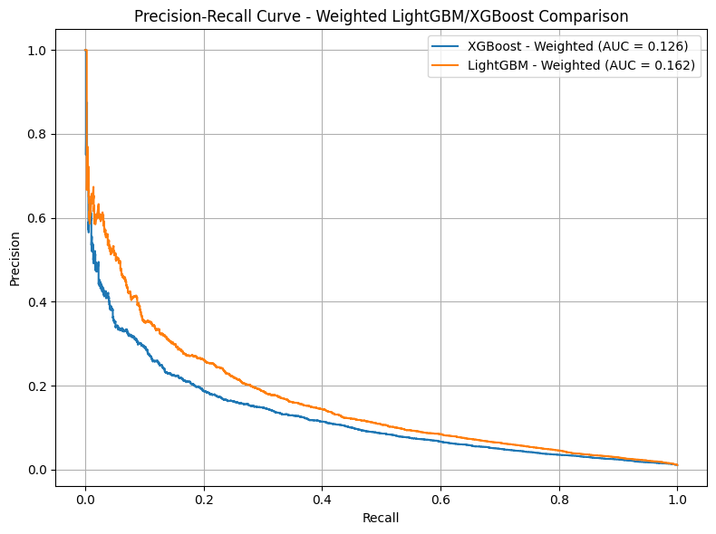

```python
def Weighted_PR_Curve(y_true, y_scores, label):
    precision, recall, _ = precision_recall_curve(y_true, y_scores)
    pr_auc = auc(recall, precision)
    plt.plot(recall, precision, label=f"{label} (AUC = {pr_auc:.3f})")

plt.figure(figsize=(8, 6))

Weighted_PR_Curve(y_test, y_score_xgb_weighted, "XGBoost - Weighted")
Weighted_PR_Curve(y_test, y_score_lgb_weighted, "LightGBM - Weighted")

plt.xlabel("Recall")
plt.ylabel("Precision")
plt.title("Precision-Recall Curve - Weighted LightGBM/XGBoost Comparison")
plt.legend()
plt.grid(True)
plt.tight_layout()
plt.savefig("assets/images/Weighted_PR_Curve.png")
plt.show()
```

What do our findings show?

- Both models massively outperform their SMOTE counterparts, proving that scale_pos_weight is the superior approach for decision trees.

Weighted LightGBM:

- Correctly identified 163,218 non-fraudulent applications.
- Misclassified 34,576 legitimate transactions as fraud.
- Missed 467 fraudulent applications.
- Successfully predicted 1,739 fraud cases.

Out of all fraud applications, only 5% of predicted frauds were correct (precision), but recall jumped to 0.79, meaning we caught nearly 80% of actual fraud cases. The F1-score of 0.09 reflects a modest but real improvement in balancing fraud detection with false positives. Although the accuracy dropped to 0.82, this is a worthwhile tradeoff for the significant increase in fraud capture — a massive improvement over the SMOTE version.

Weighted XGBoost:

- Correctly identified 179,305 non-fraudulent applications.
- Misclassified 18,489 legitimate transactions as fraud.
- Missed 882 fraud cases.
- Correctly flagged 1,324 fraudulent applications.

Here, precision on fraud predictions improved to 7%, and recall rose to 0.60, meaning 60% of fraud was successfully identified — a major step up from the original XGBoost performance. With an F1-score of 0.12 and accuracy of 0.90, this version of XGBoost strikes a better balance, delivering strong fraud recall without the excessive false alarms seen in the SMOTE model.

# Conclusion

### To recap

#### Data Prep

- Handled null values in key features such as bank_months_count, credit_risk_score, and session_length_in_minutes.
- Encoded categorical variables and applied StandardScaler to numerical features.
- Labeled target variable fraud_bool for binary classification.